# ABTest_0911_Project

```python
import pandas as pd
import numpy as np
import matplotlib.pyplot as plt
from sklearn.linear_model import LinearRegression
```

```python
import warnings
warnings.filterwarnings("ignore")
```

```python
# pd.set_option('display.max_rows', None)
# pd.set_option('display.max_columns', None)
```

## 0. Read Factors Data

Read Fama-French 5 monthly factor data.

```python
ff5= pd.read_csv(r'.\F-F_Research_Data_5_Factors_2x3_CSV\F-F_Research_Data_5_Factors_2x3.csv', skiprows=4)
```

```python
ff5.columns= ['YYYYMM', 'Mkt-RF','SMB','HML','RMW','CMA','RF']
```

```python
ff5['YYYYMM']= ff5['YYYYMM'].astype(str)
```

```python
indEnd= [x for x in range(0,len(ff5)) if ff5.iloc[x,0].isnumeric()==False][0]
```

```python
ff5= ff5.iloc[:indEnd,:]
```

```python
ff5
```

|  | YYYYMM | Mkt-RF | SMB | HML | RMW | CMA | RF |
| --- | --- | --- | --- | --- | --- | --- | --- |
| 0 | 196307 | -0.39 | -0.48 | -0.84 | 0.64 | -1.15 | 0.27 |
| 1 | 196308 | 5.08 | -0.80 | 1.72 | 0.40 | -0.38 | 0.25 |
| 2 | 196309 | -1.57 | -0.43 | -0.02 | -0.78 | 0.15 | 0.27 |
| 3 | 196310 | 2.54 | -1.34 | -0.03 | 2.79 | -2.25 | 0.29 |
| 4 | 196311 | -0.86 | -0.85 | 1.78 | -0.43 | 2.27 | 0.27 |
| ... | ... | ... | ... | ... | ... | ... | ... |
| 752 | 202603 | -5.18 | 0.67 | 3.29 | -2.03 | -0.12 | 0.29 |
| 753 | 202604 | 9.95 | 0.46 | -1.37 | -4.15 | -3.80 | 0.29 |
| 754 | 202605 | 4.91 | -2.65 | -2.31 | -8.16 | -1.46 | 0.31 |
| 755 | 202606 | -1.07 | 4.36 | 3.58 | -5.07 | 3.45 | 0.29 |
| 756 | 202607 | -0.60 | -0.12 | 2.11 | 11.05 | 2.34 | 0.33 |

757 rows × 7 columns

Read Momentum monthly factor data.

```python
umd= pd.read_csv(r'.\F-F_Momentum_Factor_CSV\F-F_Momentum_Factor.csv', skiprows=13)
```

```python
umd.columns= ['YYYYMM', 'Mom']
```

```python
umd['YYYYMM']= umd['YYYYMM'].astype(str)
```

```python
indEnd= [x for x in range(0,len(umd)) if umd.iloc[x,0].isnumeric()==False][0]
```

```python
umd= umd.iloc[:indEnd,:]
```

```python
umd
```

|  | YYYYMM | Mom |
| --- | --- | --- |
| 0 | 192701 | 0.57 |
| 1 | 192702 | -1.51 |
| 2 | 192703 | 3.52 |
| 3 | 192704 | 4.35 |
| 4 | 192705 | 2.78 |
| ... | ... | ... |
| 1190 | 202603 | 1.56 |
| 1191 | 202604 | 9.51 |
| 1192 | 202605 | 1.39 |
| 1193 | 202606 | 4.62 |
| 1194 | 202607 | -12.25 |

1195 rows × 2 columns

Combine UMD to FF5 dataset.

```python
factors= pd.merge(ff5, umd, on='YYYYMM')
```

```python
factors
```

|  | YYYYMM | Mkt-RF | SMB | HML | RMW | CMA | RF | Mom |
| --- | --- | --- | --- | --- | --- | --- | --- | --- |
| 0 | 196307 | -0.39 | -0.48 | -0.84 | 0.64 | -1.15 | 0.27 | 1.01 |
| 1 | 196308 | 5.08 | -0.80 | 1.72 | 0.40 | -0.38 | 0.25 | 1.00 |
| 2 | 196309 | -1.57 | -0.43 | -0.02 | -0.78 | 0.15 | 0.27 | 0.12 |
| 3 | 196310 | 2.54 | -1.34 | -0.03 | 2.79 | -2.25 | 0.29 | 3.13 |
| 4 | 196311 | -0.86 | -0.85 | 1.78 | -0.43 | 2.27 | 0.27 | -0.77 |
| ... | ... | ... | ... | ... | ... | ... | ... | ... |
| 752 | 202603 | -5.18 | 0.67 | 3.29 | -2.03 | -0.12 | 0.29 | 1.56 |
| 753 | 202604 | 9.95 | 0.46 | -1.37 | -4.15 | -3.80 | 0.29 | 9.51 |
| 754 | 202605 | 4.91 | -2.65 | -2.31 | -8.16 | -1.46 | 0.31 | 1.39 |
| 755 | 202606 | -1.07 | 4.36 | 3.58 | -5.07 | 3.45 | 0.29 | 4.62 |
| 756 | 202607 | -0.60 | -0.12 | 2.11 | 11.05 | 2.34 | 0.33 | -12.25 |

757 rows × 8 columns

Check to see if there is any missing value.

```python
np.sum([0 if factors.iloc[x,y]!=np.nan else 1 for x in range(0,len(factors)) for y in range(1,len(factors.columns))])
```

```
0
```

Read Indsutry portfolio monthly return data.

```python
IndPort= pd.read_csv(r'./12_Industry_Portfolios_CSV/12_Industry_Portfolios.csv', skiprows= 11)
```

```python
IndPort.columns= ['YYYYMM', 'NoDur','Durbl','Manuf','Enrgy','Chems','BusEq','Telcm','Utils','Shops','Hlth','Money','Other']
```

```python
IndPort['YYYYMM']= IndPort['YYYYMM'].astype(str)
```

```python
indEnd= [x for x in range(0,len(IndPort)) if IndPort.iloc[x,0].isnumeric()==False][0]
```

```python
IndPort= IndPort.iloc[:indEnd,:]
```

```python
ret= pd.merge(factors,IndPort,on='YYYYMM')
```

```python
ret= ret[ret['YYYYMM']>='198701']
ret.reset_index(drop=True, inplace=True)
```

```python
ret
```

|  | YYYYMM | Mkt-RF | SMB | HML | RMW | CMA | RF | Mom | NoDur | Durbl | Manuf | Enrgy | Chems | BusEq | Telcm | Utils | Shops | Hlth | Money | Other |
| --- | --- | --- | --- | --- | --- | --- | --- | --- | --- | --- | --- | --- | --- | --- | --- | --- | --- | --- | --- | --- |
| 0 | 198701 | 12.44 | -1.61 | -3.18 | 0.17 | -1.03 | 0.42 | 2.06 | 14.46 | 18.66 | 14.23 | 14.15 | 14.81 | 16.47 | 5.30 | 9.30 | 11.72 | 13.15 | 10.43 | 13.65 |
| 1 | 198702 | 4.37 | 3.36 | -5.86 | -0.79 | -2.55 | 0.43 | -2.23 | 5.61 | 3.59 | 4.81 | -1.76 | 4.66 | 9.52 | 0.03 | -2.15 | 9.81 | 11.12 | 3.94 | 6.99 |
| 2 | 198703 | 1.63 | 0.32 | 1.66 | 1.30 | 4.17 | 0.47 | 1.66 | 1.14 | 4.43 | 2.70 | 11.83 | 4.91 | 2.70 | 1.39 | -1.68 | 1.68 | 0.15 | -1.48 | 3.04 |
| 3 | 198704 | -2.09 | -1.58 | -0.36 | -0.52 | 1.16 | 0.44 | 0.21 | -3.68 | 4.11 | -2.02 | 0.11 | -0.48 | 4.43 | -2.47 | -4.33 | -2.70 | -2.45 | -4.95 | -1.42 |
| 4 | 198705 | 0.11 | -0.58 | 0.22 | 0.49 | 1.13 | 0.38 | -0.80 | 2.63 | -1.29 | 0.05 | 3.02 | 1.04 | 0.26 | 3.29 | -1.85 | -0.05 | 1.25 | -0.75 | 2.04 |
| ... | ... | ... | ... | ... | ... | ... | ... | ... | ... | ... | ... | ... | ... | ... | ... | ... | ... | ... | ... | ... |
| 470 | 202603 | -5.18 | 0.67 | 3.29 | -2.03 | -0.12 | 0.29 | 1.56 | -8.05 | -8.03 | -9.77 | 12.85 | -9.01 | -4.74 | -2.61 | -2.05 | -4.31 | -7.23 | -3.46 | -6.69 |
| 471 | 202604 | 9.95 | 0.46 | -1.37 | -4.15 | -3.80 | 0.29 | 9.51 | 2.67 | 3.32 | 9.25 | -4.15 | 2.04 | 17.82 | -2.26 | 2.05 | 11.77 | -2.06 | 9.11 | 4.07 |
| 472 | 202605 | 4.91 | -2.65 | -2.31 | -8.16 | -1.46 | 0.31 | 1.39 | -0.24 | 12.03 | 5.06 | -6.07 | -1.98 | 11.98 | -1.46 | -4.97 | -2.89 | 2.95 | -0.80 | 0.05 |
| 473 | 202606 | -1.07 | 4.36 | 3.58 | -5.07 | 3.45 | 0.29 | 4.62 | 1.58 | -2.86 | 14.78 | -5.67 | 1.91 | -5.01 | -8.98 | 2.80 | -3.75 | 7.52 | 5.27 | 1.37 |
| 474 | 202607 | -0.60 | -0.12 | 2.11 | 11.05 | 2.34 | 0.33 | -12.25 | 3.90 | -20.50 | -12.71 | 14.51 | -0.38 | -1.05 | 3.19 | -1.78 | 5.89 | 0.75 | 4.79 | 1.35 |

475 rows × 20 columns

## Question 1.

**a-1. What are the FF factor betas for each of the industry portfolios?**

```python
fbeta= pd.DataFrame(index= range(0,6), columns= IndPort.columns[1:])
falpha= fbeta.copy()
```

```python
for i in range(0,len(fbeta.columns)):
    indCol= [a for a in range(0,len(ret.columns)) if ret.columns[a]==fbeta.columns[i]][0]
    y= ret.iloc[:,indCol].values.astype(float)
    x= ret.iloc[:,[1,2,3,4,5,7]].values.astype(float)
    model= LinearRegression()
    model.fit(x,y)
    beta1= model.coef_[0]
    beta2= model.coef_[1]
    beta3= model.coef_[2]
    beta4= model.coef_[3]
    beta5= model.coef_[4]
    beta6= model.coef_[5]
    alpha= model.intercept_
    fbeta.iloc[0,i]= beta1
    fbeta.iloc[1,i]= beta2
    fbeta.iloc[2,i]= beta3
    fbeta.iloc[3,i]= beta4
    fbeta.iloc[4,i]= beta5
    fbeta.iloc[5,i]= beta6
    falpha.iloc[0,i]= alpha
```

```python
fbeta['FactorBeta']= [x for x in ret.columns[[1,2,3,4,5,7]]]
```

```python
fbeta
```

|  | NoDur | Durbl | Manuf | Enrgy | Chems | BusEq | Telcm | Utils | Shops | Hlth | Money | Other | FactorBeta |
| --- | --- | --- | --- | --- | --- | --- | --- | --- | --- | --- | --- | --- | --- |
| 0 | 0.814376 | 1.274375 | 1.156941 | 0.927389 | 0.934859 | 1.127242 | 0.913418 | 0.578885 | 0.970029 | 0.815246 | 1.080303 | 1.0551 | Mkt-RF |
| 1 | -0.003365 | 0.314928 | 0.204003 | 0.16844 | 0.028278 | 0.003638 | -0.217793 | -0.146881 | 0.15757 | -0.086827 | -0.071245 | 0.187047 | SMB |
| 2 | -0.056834 | 0.143083 | 0.170948 | 0.526154 | -0.026511 | -0.457139 | -0.033497 | 0.159589 | -0.1078 | -0.275826 | 0.78524 | 0.09272 | HML |
| 3 | 0.531128 | 0.131874 | 0.183974 | 0.220322 | 0.478841 | -0.350368 | -0.086034 | 0.177272 | 0.467622 | 0.169421 | -0.005449 | 0.144022 | RMW |
| 4 | 0.419385 | -0.120579 | 0.127714 | 0.341578 | 0.416174 | -0.305882 | 0.339735 | 0.395994 | -0.080649 | 0.394227 | -0.332229 | 0.038257 | CMA |
| 5 | 0.013402 | -0.294672 | -0.023032 | -0.015574 | -0.001952 | -0.089048 | -0.099099 | 0.085728 | -0.01185 | 0.059846 | -0.051703 | -0.06162 | Mom |

```python
falpha.dropna(inplace=True)
falpha
```

|  | NoDur | Durbl | Manuf | Enrgy | Chems | BusEq | Telcm | Utils | Shops | Hlth | Money | Other |
| --- | --- | --- | --- | --- | --- | --- | --- | --- | --- | --- | --- | --- |
| 0 | 0.090232 | 0.223578 | 0.160752 | 0.122718 | -0.050996 | 0.70405 | 0.089153 | 0.22544 | 0.232367 | 0.32867 | 0.168612 | -0.049905 |

**a-2. In regression, does it help to use 5 or 6 (includes MOM) factors or was original 3 or 4 (includes MOM) factors model adequate?**

```python
pval= pd.DataFrame(index= range(0,8), columns= fbeta.columns)
```

```python
pval['FactorBeta']= ['Alpha']+ [x for x in fbeta['FactorBeta']]+ ['Model']
```

```python
import statsmodels.api as sm

for i in range(0, len(pval.columns)-1):
    indCol= [a for a in range(0,len(ret.columns)) if ret.columns[a]==pval.columns[i]][0]
    y= ret.iloc[:,indCol].values.astype(float)
    x= ret.iloc[:,[1,2,3,4,5,7]].values.astype(float)
    x_sm = sm.add_constant(x)
    ols_model = sm.OLS(y, x_sm).fit()
    pval.iloc[:7,i]= ols_model.pvalues
    pval.iloc[7,i]= ols_model.f_pvalue
```

```python
pval
```

|  | NoDur | Durbl | Manuf | Enrgy | Chems | BusEq | Telcm | Utils | Shops | Hlth | Money | Other | FactorBeta |
| --- | --- | --- | --- | --- | --- | --- | --- | --- | --- | --- | --- | --- | --- |
| 0 | 0.406521 | 0.406218 | 0.13934 | 0.594555 | 0.655142 | 0.0 | 0.565279 | 0.149874 | 0.032799 | 0.025892 | 0.096521 | 0.547915 | Alpha |
| 1 | 0.0 | 0.0 | 0.0 | 0.0 | 0.0 | 0.0 | 0.0 | 0.0 | 0.0 | 0.0 | 0.0 | 0.0 | Mkt-RF |
| 2 | 0.93059 | 0.001062 | 0.0 | 0.040275 | 0.486034 | 0.934217 | 0.000089 | 0.008476 | 0.000052 | 0.097384 | 0.04834 | 0.0 | SMB |
| 3 | 0.226039 | 0.218394 | 0.000294 | 0.0 | 0.590687 | 0.0 | 0.61671 | 0.018422 | 0.02184 | 0.000017 | 0.0 | 0.00995 | HML |
| 4 | 0.0 | 0.258408 | 0.000106 | 0.027823 | 0.0 | 0.0 | 0.200675 | 0.00915 | 0.0 | 0.008116 | 0.901212 | 0.000072 | RMW |
| 5 | 0.0 | 0.474678 | 0.061089 | 0.018399 | 0.0 | 0.000094 | 0.000511 | 0.000062 | 0.236316 | 0.000023 | 0.0 | 0.46233 | CMA |
| 6 | 0.581236 | 0.000001 | 0.343091 | 0.762508 | 0.939031 | 0.001397 | 0.00441 | 0.014512 | 0.625516 | 0.06934 | 0.022804 | 0.000966 | Mom |
| 7 | 0.0 | 0.0 | 0.0 | 0.0 | 0.0 | 0.0 | 0.0 | 0.0 | 0.0 | 0.0 | 0.0 | 0.0 | Model |

In terms of all factors, all models are statistical significant enough(p values< 0.05) under the 95% confidence level. However, if we look into the significance for all factors coefficients, except for market excess return(Mkt-RF), some other factors still fail to reject the null hypothesis under 95% confidence level.

So if we need to compare the goodness of fit, prediction power and risk of overfitting in the regression model, AIC, BIC and adjusted R-squared are three major criterions applied for the examination.

```python
AllFactors= pd.DataFrame(index= range(0,3), columns= fbeta.columns[:-1])
FourFactors= pd.DataFrame(index= range(0,3), columns= fbeta.columns[:-1])
```

```python
AllFactors['Examination']= ['AdjR2', 'AIC', 'BIC']
FourFactors['Examination']= ['AdjR2', 'AIC', 'BIC']
```

```python
for i in range(0, len(AllFactors.columns)-1):
    indCol= [a for a in range(0,len(ret.columns)) if ret.columns[a]==AllFactors.columns[i]][0]
    y= ret.iloc[:,indCol].values.astype(float)
    x= ret.iloc[:,[1,2,3,4,5,7]].values.astype(float)
    x_sm = sm.add_constant(x)
    ols_model = sm.OLS(y, x_sm).fit()
    AllFactors.iloc[0,i]= ols_model.rsquared_adj
    AllFactors.iloc[1,i]= ols_model.aic
    AllFactors.iloc[2,i]= ols_model.bic
```

```python
for i in range(0, len(FourFactors.columns)-1):
    indCol= [a for a in range(0,len(ret.columns)) if ret.columns[a]==FourFactors.columns[i]][0]
    y= ret.iloc[:,indCol].values.astype(float)
    x= ret.iloc[:,[1,2,3,7]].values.astype(float)
    x_sm = sm.add_constant(x)
    ols_model = sm.OLS(y, x_sm).fit()
    FourFactors.iloc[0,i]= ols_model.rsquared_adj
    FourFactors.iloc[1,i]= ols_model.aic
    FourFactors.iloc[2,i]= ols_model.bic
```

```python
AllFactors
```

|  | NoDur | Durbl | Manuf | Enrgy | Chems | BusEq | Telcm | Utils | Shops | Hlth | Money | Other | Examination |
| --- | --- | --- | --- | --- | --- | --- | --- | --- | --- | --- | --- | --- | --- |
| 0 | 0.688952 | 0.565669 | 0.839783 | 0.449858 | 0.726976 | 0.855935 | 0.606056 | 0.348812 | 0.78928 | 0.550852 | 0.85906 | 0.886523 | AdjR2 |
| 1 | 2125.055201 | 2986.452204 | 2124.60565 | 2839.528208 | 2171.956698 | 2250.304563 | 2462.518342 | 2470.869697 | 2124.417342 | 2412.971912 | 2058.384785 | 1869.474177 | AIC |
| 2 | 2154.198404 | 3015.595408 | 2153.748854 | 2868.671411 | 2201.099901 | 2279.447767 | 2491.661545 | 2500.012901 | 2153.560545 | 2442.115116 | 2087.527988 | 1898.617381 | BIC |

```python
FourFactors
```

|  | NoDur | Durbl | Manuf | Enrgy | Chems | BusEq | Telcm | Utils | Shops | Hlth | Money | Other | Examination |
| --- | --- | --- | --- | --- | --- | --- | --- | --- | --- | --- | --- | --- | --- |
| 0 | 0.584978 | 0.565786 | 0.834272 | 0.440499 | 0.656917 | 0.839448 | 0.595711 | 0.32076 | 0.744628 | 0.529495 | 0.851433 | 0.883062 | AdjR2 |
| 1 | 2260.063819 | 2984.349319 | 2138.694223 | 2845.566431 | 2278.478043 | 2299.797557 | 2472.856543 | 2488.92871 | 2213.734116 | 2433.06347 | 2081.443315 | 1881.772567 | AIC |
| 2 | 2280.880393 | 3005.165893 | 2159.510797 | 2866.383005 | 2299.294617 | 2320.614131 | 2493.673117 | 2509.745284 | 2234.55069 | 2453.880044 | 2102.259889 | 1902.589141 | BIC |

In the goodness of fit, almost every industry portfolio, except for Durbl, exhibited higher explained variations(higher adjusted R2) in the 6 factors model.  
In the prediction power measurement, almost every industry portfolio, except for Durbl, performed higher prediction power in the 6 factors model(lower AIC).  
In the risk of overfitting, almost every industry portfolio, except for Durbl and Enrgy, performed lower overfitting possibilities in the 6 factors model(lower BIC).

Overall speaking, 6 factors model should be superior to the 4 factors model, due to the improvements in adjusted R squared, AIC and BIC measurements.

**a-3. Are these betas time varying?**

Since these betas represented regression coefficients in the model, they are affected by the return time series data and the modeling periods. So they are indeed time varying.

**b. What regression technique can one employ to find more stable beta? How do your results change?**

Since betas and the results of regression are easily affected by the time series data used for training model, either adopting AR/Adaptive/Regime types of beta modeling should improve the stability.

Consider AR-type model, we use autoregressive model to assume historical beta follow a distribution with characteristic of reverting, then solving techniques like Kalman Filter can be adopted on. In terms of adaptive modeling, we increase the weights of closer-date return, in order to better capturing and reflecting the latest fluctuations in the return time series data. As for regime-type model, we can carefully split the time series return data by other facets, either by statistical methodology like HMM to recognize different regimes, or by economic rationale and related observed indicators to classify the data to different scenarios, then we used different kinds of smoothing and predicting model in different regimes.

The original version of static betas measurement should be good for attibutions and posterior analysis. However, when it comes to priori prediction and analysis, time varying/regime depending betas measurement should be more beneficial in constructing portfolios. The time varying results should be less volatile since it contains smoothing in the modeling, and the regime depending results should demonstrate only less volatile in the same states, the change should be more dramastic if we compare results in different regimes.

## Question 2.

Which industry portfolios are closely related to each other (how many groups exist – a fundamental analyst may say there are two groups - defensive and cyclical)? Does this relationship/group composition change through time? What technique/s can you use to show this – why did you choose your technique over others?

```python
corTab= IndPort.iloc[:,1:].corr()
```

```python
corTab
```

|  | NoDur | Durbl | Manuf | Enrgy | Chems | BusEq | Telcm | Utils | Shops | Hlth | Money | Other |
| --- | --- | --- | --- | --- | --- | --- | --- | --- | --- | --- | --- | --- |
| NoDur | 1.000000 | 0.671917 | 0.819341 | 0.603309 | 0.831825 | 0.715637 | 0.677460 | 0.704859 | 0.846804 | 0.787406 | 0.823148 | 0.808418 |
| Durbl | 0.671917 | 1.000000 | 0.813416 | 0.546929 | 0.747020 | 0.747716 | 0.575055 | 0.558466 | 0.759137 | 0.583170 | 0.746701 | 0.754023 |
| Manuf | 0.819341 | 0.813416 | 1.000000 | 0.697077 | 0.881540 | 0.850640 | 0.662673 | 0.672948 | 0.827712 | 0.727607 | 0.863407 | 0.910340 |
| Enrgy | 0.603309 | 0.546929 | 0.697077 | 1.000000 | 0.651703 | 0.570758 | 0.518889 | 0.577668 | 0.561646 | 0.534745 | 0.662571 | 0.663006 |
| Chems | 0.831825 | 0.747020 | 0.881540 | 0.651703 | 1.000000 | 0.778472 | 0.655763 | 0.679890 | 0.797540 | 0.752533 | 0.808396 | 0.810779 |
| BusEq | 0.715637 | 0.747716 | 0.850640 | 0.570758 | 0.778472 | 1.000000 | 0.657790 | 0.612907 | 0.792862 | 0.704161 | 0.779120 | 0.811764 |
| Telcm | 0.677460 | 0.575055 | 0.662673 | 0.518889 | 0.655763 | 0.657790 | 1.000000 | 0.616465 | 0.666785 | 0.590878 | 0.704684 | 0.678647 |
| Utils | 0.704859 | 0.558466 | 0.672948 | 0.577668 | 0.679890 | 0.612907 | 0.616465 | 1.000000 | 0.640990 | 0.609859 | 0.747067 | 0.672540 |
| Shops | 0.846804 | 0.759137 | 0.827712 | 0.561646 | 0.797540 | 0.792862 | 0.666785 | 0.640990 | 1.000000 | 0.734436 | 0.822922 | 0.811068 |
| Hlth | 0.787406 | 0.583170 | 0.727607 | 0.534745 | 0.752533 | 0.704161 | 0.590878 | 0.609859 | 0.734436 | 1.000000 | 0.741826 | 0.713084 |
| Money | 0.823148 | 0.746701 | 0.863407 | 0.662571 | 0.808396 | 0.779120 | 0.704684 | 0.747067 | 0.822922 | 0.741826 | 1.000000 | 0.864837 |
| Other | 0.808418 | 0.754023 | 0.910340 | 0.663006 | 0.810779 | 0.811764 | 0.678647 | 0.672540 | 0.811068 | 0.713084 | 0.864837 | 1.000000 |

In the preliminary analysis, we can see from the correlation table, there are a few combinations of the industry portfolios that are highly related to each other. In order to classifying these industry portfolios into different groups, we can use hierarchical clustering method to achieve our goal.

```python
from scipy.cluster.hierarchy import linkage, dendrogram, fcluster
from scipy.spatial.distance import squareform
from sklearn.metrics import silhouette_score


distance_matrix = np.sqrt(0.5 * (1 - corTab))
condensed_distance = squareform(distance_matrix)
Z = linkage(condensed_distance, method='ward')

best_score=-1
best_k= 2
for k in range(2,7):
    test_labels= fcluster(Z, t=k, criterion='maxclust')
    score= silhouette_score(distance_matrix, test_labels, metric='precomputed')

    if score> best_score:
        best_score= score
        best_k= k

print(best_k)
final_clusters= fcluster(Z, t= best_k, criterion='maxclust')

group_results = pd.DataFrame({'Industry': corTab.columns, 'Cluster': final_clusters})
print(group_results.sort_values('Cluster'))
```

```
2
   Industry  Cluster
0     NoDur        1
1     Durbl        1
2     Manuf        1
4     Chems        1
5     BusEq        1
8     Shops        1
9      Hlth        1
10    Money        1
11    Other        1
3     Enrgy        2
6     Telcm        2
7     Utils        2
```

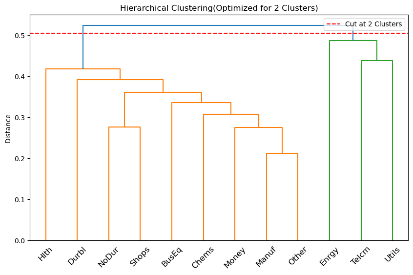

```python
cut_distance= (Z[-best_k, 2]+ Z[-(best_k- 1), 2])/2
plt.figure(figsize=(10,6))

dendrogram(Z, labels= corTab.columns, leaf_rotation=45, leaf_font_size=12, color_threshold=cut_distance)

plt.axhline(y= cut_distance, color='r', linestyle='--', label=f'Cut at {best_k} Clusters')
plt.title(f'Hierarchical Clustering(Optimized for {best_k} Clusters)')
plt.ylabel('Distance')
plt.legend()
plt.show()
```

From the result of hierarchical clustering, the whole 12 sectors should be divided into two groups. Enrgy, Telcm and Utils behave in consistency in all industries, so they are classified into one group.

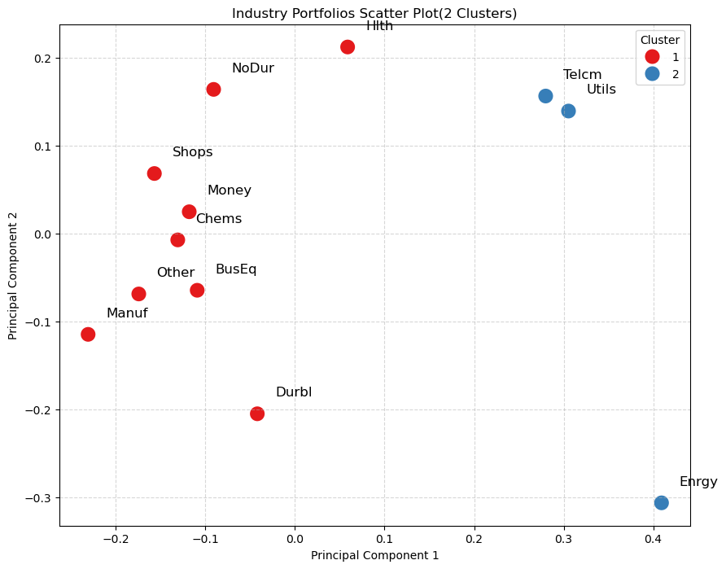

```python
from sklearn.decomposition import PCA
import seaborn as sns

pca= PCA(n_components= 2)
coords= pca.fit_transform(distance_matrix)

plot_df= pd.DataFrame({
    'X': coords[:,0],
    'Y': coords[:,1],
    'Industry': corTab.columns,
    'Cluster': final_clusters
})

plt.figure(figsize=(10,8))
sns.scatterplot(data= plot_df, x='X',y='Y', hue='Cluster', palette='Set1',s=200)

for i in range(plot_df.shape[0]):
    plt.text(plot_df['X'][i]+ 0.02, plot_df['Y'][i]+ 0.02, plot_df['Industry'][i], fontsize=12)

plt.title(f'Industry Portfolios Scatter Plot({best_k} Clusters)')
plt.xlabel('Principal Component 1')
plt.ylabel('Principal Component 2')
plt.grid(True, linestyle='--', alpha=0.5)
plt.show()
```

We can also project the industry correlation and distance onto other coordinate system, generally speaking, we can see from the plot that industries fall into two distinct clusters.

The clusters will be changing as time varies. If we adopt walk forward algorithm, instead of using dataset from the whole period, we only look back the data from certain days ago to train the model, the result should be different but still in consistent with the latest market structure, and the time-varying clusters difference can be demonstrated once the clustering follow rolling-type analysis.

Either supervised or unsupervised algorithms in machine learning area can attain similar groupings, but the main reason of using unsupervised algorithm, hierarchical clustering, lies in the absence of given parameters. If other algorithms adopted like K means or KNN, we need to specify a parameter to tell the model to classify the data into K groups or K members in a group, then the model will forcely split the data into the setting groups or members, this will result in very different industries but be classified as the same group sometimes. We used hierarchical clustering to allow the data reveal itself.

## Question 3.

**Construct minimum variance portfolio with constraints of not more than 50% allocation to each group that you found in no.2. Compare it with equal weighted 12 industry portfolio. Do monthly rebalancing for both.**

min $\sigma^2= w^T \Sigma w$

st $\Sigma_{i} w_i=1, \forall i=[1,2]$

```python
w= pd.DataFrame(index= IndPort.index, columns= IndPort.columns)
```

```python
w['YYYYMM']= IndPort['YYYYMM']
```

```python
w.fillna(0, inplace=True)
```

We follow the instruction and use the static classification result from question 2, but the training data starts from 192607 to the latest available month. However, in more pragmatic and my favorable way is to constructing the backtest in a walk foward way, only look back the returns and the data in past certain years or given durations each month.

```python
from scipy.optimize import minimize
industries= ['NoDur', 'Durbl','Manuf','Enrgy','Chems','BusEq','Telcm','Utils','Shops','Hlth','Money','Other']
cov_mat= IndPort.iloc[:,1:].cov().values
num_assets= len(industries)

clust1_industry= ['Enrgy', 'Utils', 'Telcm']
clust2_industry= [x for x in industries if x not in clust1_industry]
ind_c1= [industries.index(x) for x in clust1_industry]
ind_c2= [industries.index(x) for x in clust2_industry]

def port_var(weights, cov_mat):
    return weights.T@cov_mat@weights

constraints=[
    #sum=1: {sum(w)-1=0}
    {'type': 'eq', 'fun': lambda w:np.sum(w)-1},
    #c1 sum<=0.5: {0.5-sum(w_c1)>=0}
    {'type':'eq', 'fun':lambda w:0.5-np.sum(w[ind_c1])},
    #c2 sum<=0.5: {0.5-sum(w_c2)>=0}
    {'type':'eq', 'fun':lambda w:0.5-np.sum(w[ind_c2])}
]
```

```python
def MVO_w(cov_mat, constraints, num_assets):
    bounds= tuple((0,1) for _ in range(num_assets))
    init_guess= np.ones(num_assets)/num_assets

    optimized_result= minimize(
        port_var,
        init_guess,
        args=(cov_mat,),
        method='SLSQP',
        bounds=bounds,
        constraints= constraints,
        tol= 1e-9
    )

    finalw1={}
    finalw2={}
    if optimized_result.success:
        optimal_weights= optimized_result.x
        sum_c1= 0
        for idx in ind_c1:
            weight= optimal_weights[idx]
            sum_c1+= weight
            if weight> 0.0001:
                finalw1[industries[idx]]= round(weight*100,4)

        sum_c2= 0
        for idx in ind_c2:
            weight= optimal_weights[idx]
            sum_c2+= weight
            if weight> 0.0001:
                finalw2[industries[idx]]= round(weight*100,4)
    return finalw1, finalw2
```

```python
%%time
for i in range(0,len(w)):
    df= IndPort.iloc[[x for x in range(0,len(IndPort)) if IndPort.iloc[x,0]<= w.iloc[i,0]],:]
    cov_mat= df.iloc[:,1:].cov().values
    num_assets= len(industries)
    result= MVO_w(cov_mat, constraints, num_assets)
    for j in range(1,len(w.columns)):
        for k in [y for y in result[0].keys()]:
            if w.columns[j]==k:
                w.iloc[i,j]= result[0][k]

        for k in [y for y in result[1].keys()]:
            if w.columns[j]==k:
                w.iloc[i,j]= result[1][k]
```

```
CPU times: total: 10min 2s
Wall time: 1min 15s
```

```python
w['SumW']= 0
for i in range(0,len(w)):
    cumsum= 0
    for j in range(1,len(w.columns)-1):
        cumsum+= w.iloc[i,j]
    w.iloc[i,-1]= cumsum
```

```python
w
```

|  | YYYYMM | NoDur | Durbl | Manuf | Enrgy | Chems | BusEq | Telcm | Utils | Shops | Hlth | Money | Other | SumW |
| --- | --- | --- | --- | --- | --- | --- | --- | --- | --- | --- | --- | --- | --- | --- |
| 0 | 192607 | 0.0000 | 0.0000 | 0.0000 | 0.0000 | 0.0000 | 0.0 | 0.0000 | 0.0000 | 0.0000 | 0.0000 | 0.0000 | 0.0000 | 0.0000 |
| 1 | 192608 | 0.0000 | 28.8355 | 0.0000 | 50.0000 | 0.0000 | 0.0 | 0.0000 | 0.0000 | 0.0000 | 0.0000 | 21.1645 | 0.0000 | 100.0000 |
| 2 | 192609 | 4.2021 | 0.0447 | 0.0618 | 0.1809 | 2.0066 | 0.0 | 32.8291 | 16.9900 | 43.6105 | 0.0743 | 0.0000 | 0.0000 | 100.0000 |
| 3 | 192610 | 4.2173 | 0.0000 | 0.0000 | 6.2721 | 0.0000 | 0.0 | 43.7279 | 0.0000 | 45.7827 | 0.0000 | 0.0000 | 0.0000 | 100.0000 |
| 4 | 192611 | 25.1691 | 0.0000 | 0.0000 | 0.0000 | 0.0000 | 0.0 | 50.0000 | 0.0000 | 0.7485 | 19.3234 | 0.0000 | 4.7589 | 99.9999 |
| ... | ... | ... | ... | ... | ... | ... | ... | ... | ... | ... | ... | ... | ... | ... |
| 1196 | 202603 | 49.9625 | 0.0000 | 0.0000 | 0.0000 | 0.0375 | 0.0 | 0.0000 | 50.0000 | 0.0000 | 0.0000 | 0.0000 | 0.0000 | 100.0000 |
| 1197 | 202604 | 4.2173 | 0.0000 | 0.0000 | 0.0000 | 0.0000 | 0.0 | 50.0000 | 0.0000 | 0.0000 | 45.7827 | 0.0000 | 0.0000 | 100.0000 |
| 1198 | 202605 | 4.2173 | 0.0000 | 0.0000 | 0.0000 | 0.0000 | 0.0 | 50.0000 | 0.0000 | 0.0000 | 45.7827 | 0.0000 | 0.0000 | 100.0000 |
| 1199 | 202606 | 4.2173 | 0.0000 | 0.0000 | 0.0000 | 32.7107 | 0.0 | 48.9267 | 1.0733 | 0.0000 | 13.0720 | 0.0000 | 0.0000 | 100.0000 |
| 1200 | 202607 | 4.2173 | 0.0000 | 0.0000 | 0.0000 | 0.0000 | 0.0 | 50.0000 | 0.0000 | 0.0000 | 45.7827 | 0.0000 | 0.0000 | 100.0000 |

1201 rows × 14 columns

MVO BackTest

```python
w= w[w['YYYYMM']>='198701']
w.reset_index(drop=True, inplace=True)
```

```python
cumret_mvo= pd.DataFrame(index= w.index, columns=w.columns)
```

```python
cumret_mvo['YYYYMM']= w['YYYYMM']
cumret_mvo.fillna(0,inplace=True)
```

```python
for x in cumret_mvo.columns[1:-1]:
    cumret_mvo[x]= ret[x].astype(float)/100*w[x].astype(float).shift(1)/100
```

```python
cumret_mvo.columns= [x for x in cumret_mvo.columns[:-1]]+['port_ret']
```

```python
cumret_mvo['port_ret']= 0
for i in range(0,len(cumret_mvo)):
    cumsum= 0
    for j in range(1,len(cumret_mvo.columns)-1):
        cumsum+= cumret_mvo.iloc[i,j]
    cumret_mvo.iloc[i,-1]= cumsum
```

```python
cumret_mvo.fillna(0, inplace=True)
```

```python
cumret_mvo['cum_ret']=(1+ cumret_mvo['port_ret']).cumprod()
```

```python
cumret_mvo['DD']= 0
for i in range(0,len(cumret_mvo)):
    cumret_mvo.iloc[i,-1]= min(0, cumret_mvo.iloc[i,14]- np.max(cumret_mvo.iloc[:i,14]))
```

```python
cumret_mvo
```

|  | YYYYMM | NoDur | Durbl | Manuf | Enrgy | Chems | BusEq | Telcm | Utils | Shops | Hlth | Money | Other | port_ret | cum_ret | DD |
| --- | --- | --- | --- | --- | --- | --- | --- | --- | --- | --- | --- | --- | --- | --- | --- | --- |
| 0 | 198701 | 0.000000 | 0.0 | 0.0 | 0.0 | 0.000000 | 0.0 | 0.000000 | 0.000000 | 0.000000 | 0.000000 | 0.0 | 0.0 | 0.000000 | 1.000000 | 0.000000 |
| 1 | 198702 | 0.022437 | 0.0 | 0.0 | -0.0 | 0.000000 | 0.0 | 0.000150 | -0.000000 | 0.000000 | 0.011127 | 0.0 | 0.0 | 0.033713 | 1.033713 | 0.000000 |
| 2 | 198703 | 0.000481 | 0.0 | 0.0 | 0.0 | 0.002305 | 0.0 | 0.006950 | -0.000000 | 0.001355 | 0.000495 | -0.0 | 0.0 | 0.011586 | 1.045690 | 0.000000 |
| 3 | 198704 | -0.018386 | 0.0 | -0.0 | 0.0 | -0.000000 | 0.0 | -0.012350 | -0.000000 | -0.000000 | -0.000009 | -0.0 | -0.0 | -0.030745 | 1.013540 | -0.032150 |
| 4 | 198705 | 0.004221 | -0.0 | 0.0 | 0.0 | 0.001277 | 0.0 | 0.016450 | -0.000000 | -0.000000 | 0.002709 | -0.0 | 0.0 | 0.024657 | 1.038531 | -0.007160 |
| ... | ... | ... | ... | ... | ... | ... | ... | ... | ... | ... | ... | ... | ... | ... | ... | ... |
| 470 | 202603 | -0.000000 | -0.0 | -0.0 | 0.0 | -0.000000 | -0.0 | -0.000000 | -0.000000 | -0.000000 | -0.000000 | -0.0 | -0.0 | 0.000000 | 46.608672 | -0.288032 |
| 471 | 202604 | 0.013340 | 0.0 | 0.0 | -0.0 | 0.000008 | 0.0 | -0.000000 | 0.010250 | 0.000000 | -0.000000 | 0.0 | 0.0 | 0.023598 | 47.708526 | 0.000000 |
| 472 | 202605 | -0.000101 | 0.0 | 0.0 | -0.0 | -0.000000 | 0.0 | -0.007300 | -0.000000 | -0.000000 | 0.013506 | -0.0 | 0.0 | 0.006105 | 47.999772 | 0.000000 |
| 473 | 202606 | 0.000666 | -0.0 | 0.0 | -0.0 | 0.000000 | -0.0 | -0.044900 | 0.000000 | -0.000000 | 0.034429 | 0.0 | 0.0 | -0.009805 | 47.529130 | -0.470641 |
| 474 | 202607 | 0.001645 | -0.0 | -0.0 | 0.0 | -0.001243 | -0.0 | 0.015608 | -0.000191 | 0.000000 | 0.000980 | 0.0 | 0.0 | 0.016799 | 48.327558 | 0.000000 |

475 rows × 16 columns

BM BackTest

```python
BMRet_ew= pd.read_csv(r'./12_Industry_Portfolios_CSV/12_Industry_Portfolios.csv', skiprows= 11)
```

```python
BMRet_ew.columns=['YYYYMM', 'NoDur','Durbl','Manuf','Enrgy','Chems','BusEq','Telcm','Utils','Shops','Hlth','Money','Other']
```

```python
BMRet_ew['YYYYMM']= BMRet_ew['YYYYMM'].astype(str)
```

```python
BMRet_ew
```

|  | YYYYMM | NoDur | Durbl | Manuf | Enrgy | Chems | BusEq | Telcm | Utils | Shops | Hlth | Money | Other |
| --- | --- | --- | --- | --- | --- | --- | --- | --- | --- | --- | --- | --- | --- |
| 0 | 192607 | 1.44 | 15.58 | 3.67 | -1.14 | 8.02 | 3.15 | 0.83 | 7.04 | 0.12 | 1.85 | -0.02 | 2.23 |
| 1 | 192608 | 3.99 | 3.70 | 2.41 | 3.43 | 5.10 | 1.98 | 2.17 | -1.70 | -0.72 | 4.17 | 4.26 | 4.35 |
| 2 | 192609 | 1.15 | 4.98 | -0.07 | -3.30 | 5.38 | -0.35 | 2.42 | 2.05 | 0.21 | 0.69 | -1.63 | 0.39 |
| 3 | 192610 | -1.24 | -8.39 | -3.18 | -0.78 | -4.55 | -5.38 | -0.11 | -3.27 | -2.29 | -0.57 | -5.52 | -2.75 |
| 4 | 192611 | 5.21 | -0.17 | 4.03 | 0.01 | 5.09 | 4.79 | 1.63 | 4.40 | 6.45 | 5.43 | 2.54 | 2.11 |
| ... | ... | ... | ... | ... | ... | ... | ... | ... | ... | ... | ... | ... | ... |
| 5214 | 2023 | 0.27 | 0.28 | 0.28 | 0.45 | 0.21 | 0.18 | 0.63 | 0.47 | 0.21 | 0.21 | 0.49 | 0.36 |
| 5215 | 2024 | 0.29 | 0.25 | 0.25 | 0.51 | 0.23 | 0.11 | 0.60 | 0.52 | 0.15 | 0.19 | 0.54 | 0.31 |
| 5216 | 2025 | 0.30 | 0.18 | 0.22 | 0.56 | 0.23 | 0.10 | 0.55 | 0.43 | 0.13 | 0.20 | 0.47 | 0.28 |
| 5217 | 2026 | 0.31 | 0.13 | 0.17 | 0.58 | 0.26 | 0.11 | 0.54 | 0.43 | 0.16 | 0.20 | 0.46 | 0.30 |
| 5218 | Copyright 2026 Eugene F. Fama and Kenneth R. F... | NaN | NaN | NaN | NaN | NaN | NaN | NaN | NaN | NaN | NaN | NaN | NaN |

5219 rows × 13 columns

```python
indStart= [x for x in range(0, len(BMRet_ew)) if BMRet_ew.iloc[x,0].isnumeric()==False][1]
```

```python
indEnd= [x for x in range(0, len(BMRet_ew)) if BMRet_ew.iloc[x,0].isnumeric()==False][2]
```

```python
BMRet_ew= BMRet_ew.iloc[indStart+1:indEnd,:]
```

```python
BMRet_ew.reset_index(drop=True, inplace=True)
```

```python
BMRet_ew= BMRet_ew[BMRet_ew['YYYYMM']>='198701']
BMRet_ew.reset_index(drop=True, inplace=True)
```

```python
cumret_bm=pd.DataFrame(index=BMRet_ew.index, columns=BMRet_ew.columns)
```

```python
cumret_bm['YYYYMM']= BMRet_ew['YYYYMM']
```

```python
cumret_bm.fillna(0, inplace=True)
```

```python
for x in cumret_bm.columns[1:]:
    cumret_bm[x]= BMRet_ew[x].astype(float)/100/12
```

```python
cumret_bm['port_ret']= 0
for i in range(0,len(cumret_bm)):
    cumsum= 0
    for j in range(1,len(cumret_bm.columns)-1):
        cumsum+= cumret_bm.iloc[i,j]
    cumret_bm.iloc[i,-1]= cumsum
```

```python
cumret_bm.fillna(0, inplace=True)
```

```python
cumret_bm.iloc[0,1:]= 0
```

```python
cumret_bm['cum_ret']=(1+ cumret_bm['port_ret']).cumprod()
```

```python
cumret_bm['DD']= 0
for i in range(0,len(cumret_bm)):
    cumret_bm.iloc[i,-1]= min(0, cumret_bm.iloc[i,14]- np.max(cumret_bm.iloc[:i,14]))
```

```python
cumret_bm
```

|  | YYYYMM | NoDur | Durbl | Manuf | Enrgy | Chems | BusEq | Telcm | Utils | Shops | Hlth | Money | Other | port_ret | cum_ret | DD |
| --- | --- | --- | --- | --- | --- | --- | --- | --- | --- | --- | --- | --- | --- | --- | --- | --- |
| 0 | 198701 | 0.000000 | 0.000000 | 0.000000 | 0.000000 | 0.000000 | 0.000000 | 0.000000 | 0.000000 | 0.000000 | 0.000000 | 0.000000 | 0.000000 | 0.000000 | 1.000000 | 0.000000 |
| 1 | 198702 | 0.005800 | 0.005400 | 0.006708 | 0.005242 | 0.006883 | 0.008917 | 0.005075 | -0.000050 | 0.006158 | 0.012100 | 0.004283 | 0.005658 | 0.072175 | 1.072175 | 0.000000 |
| 2 | 198703 | 0.003525 | 0.001825 | 0.003458 | 0.011858 | 0.001500 | 0.000758 | 0.005233 | -0.000158 | 0.001542 | 0.002558 | 0.000808 | 0.004383 | 0.037292 | 1.112158 | 0.000000 |
| 3 | 198704 | -0.002692 | -0.000867 | -0.001675 | 0.002325 | -0.001508 | -0.000458 | -0.002283 | -0.003650 | -0.002475 | -0.002275 | -0.002700 | -0.001108 | -0.019367 | 1.090619 | -0.021539 |
| 4 | 198705 | -0.000458 | 0.001792 | 0.001383 | 0.006000 | 0.000167 | 0.000475 | 0.001592 | -0.000767 | -0.001192 | -0.000933 | -0.001600 | 0.000525 | 0.006983 | 1.098236 | -0.013923 |
| ... | ... | ... | ... | ... | ... | ... | ... | ... | ... | ... | ... | ... | ... | ... | ... | ... |
| 470 | 202603 | -0.007692 | -0.007508 | -0.004917 | 0.010792 | 0.000867 | -0.003525 | -0.002967 | -0.000842 | -0.004550 | -0.005225 | -0.002325 | -0.005133 | -0.033025 | 44.550776 | -4.599054 |
| 471 | 202604 | 0.003317 | 0.009517 | 0.010175 | 0.000908 | 0.004033 | 0.012617 | 0.017592 | 0.000683 | 0.006233 | 0.004558 | 0.006192 | 0.007150 | 0.082975 | 48.247377 | -0.902453 |
| 472 | 202605 | -0.002642 | 0.002675 | 0.003675 | -0.006533 | -0.000258 | 0.013108 | -0.001883 | -0.002142 | 0.000933 | 0.005267 | -0.000025 | 0.001075 | 0.013250 | 48.886655 | -0.263175 |
| 473 | 202606 | 0.008125 | -0.000558 | 0.013625 | -0.004158 | -0.003875 | -0.001917 | 0.000425 | 0.001975 | 0.002808 | 0.001250 | 0.005492 | 0.001008 | 0.024200 | 50.069712 | 0.000000 |
| 474 | 202607 | -0.002317 | -0.005433 | -0.007233 | 0.003975 | -0.001433 | -0.004825 | -0.003358 | -0.002150 | -0.000533 | -0.005317 | 0.001000 | -0.003550 | -0.031175 | 48.508788 | -1.560923 |

475 rows × 16 columns

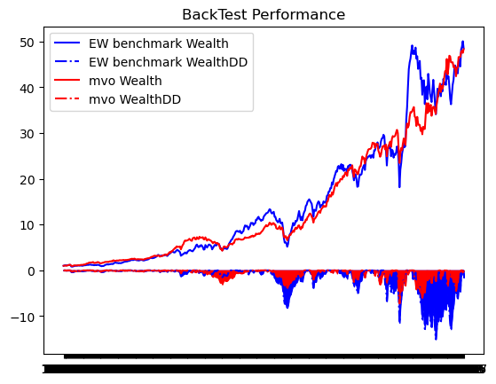

```python
plt.plot(cumret_bm['YYYYMM'], cumret_bm['cum_ret'], color= 'blue', label='EW benchmark Wealth')
plt.plot(cumret_bm['YYYYMM'], cumret_bm['DD'], color='blue', linestyle='-.',label='EW benchmark WealthDD')
plt.fill_between(cumret_bm['YYYYMM'], cumret_bm['DD'], color='blue')
plt.plot(cumret_mvo['YYYYMM'], cumret_mvo['cum_ret'], color= 'red', label='mvo Wealth')
plt.plot(cumret_mvo['YYYYMM'], cumret_mvo['DD'], color='red', linestyle='-.',label='mvo WealthDD')
plt.fill_between(cumret_mvo['YYYYMM'], cumret_mvo['DD'], color='red')
plt.legend()
plt.title('BackTest Performance')
```

```python
Retbm= np.average(cumret_bm['port_ret'])*12
print('Average annualized return of bm= ', str(Retbm))
```

```
Average annualized return of bm=  0.11812042105263158
```

```python
Retmvo= np.average(cumret_mvo['port_ret'])*12
print('Average annualized return of mvo= ', str(Retmvo))
```

```
Average annualized return of mvo=  0.10841222870652631
```

```python
Volbm= np.std(cumret_bm['port_ret'], ddof=1)*np.sqrt(12)
print('Annualized volatility of bm= ', str(Volbm))
```

```
Annualized volatility of bm=  0.19696915912640048
```

```python
Volmvo= np.std(cumret_mvo['port_ret'], ddof=1)*np.sqrt(12)
print('Annualized volatilityof mvo= ', str(Volmvo))
```

```
Annualized volatilityof mvo=  0.14138417590282704
```

```python
factors['RF']= factors['RF'].astype(float)
SRbm= (Retbm- np.average(factors['RF'])*12/100)/Volbm
print('Sharpe Ratio of bm= ', str(SRbm))
```

```
Sharpe Ratio of bm=  0.37861179256012845
```

```python
factors['RF']= factors['RF'].astype(float)
SRmvo= (Retmvo- np.average(factors['RF'])*12/100)/Volmvo
print('Sharpe Ratio of mvo= ', str(SRmvo))
```

```
Sharpe Ratio of mvo=  0.45879712956268237
```